# Time series data in R

Miao Cai

12/20/2018

# 1 Working with dates

```r
# load("TimeSeriesR/SXtemp.Rdata")
#
# require(tidyverse)
#
# datong = SXtemp %>%
#   filter(city == "datong", county == "datong")
#
# save(datong, file = "TimeSeriesR/datong.Rdata")
load("datong.Rdata")
require(tidyverse)
```

## 1.1 Convert to time series data format

```
xtdat = xts(
  x,
  order.by = index(x)
  )
```

Where:

- `x`: an object containing the time series data
- `order.by`: a corresponding vector of unique times/dates - must be of a known time-based class. See detail

A link that may be useful to read about `xts` package: https://www.datacamp.com/community/blog/r-xts-cheat-sheet

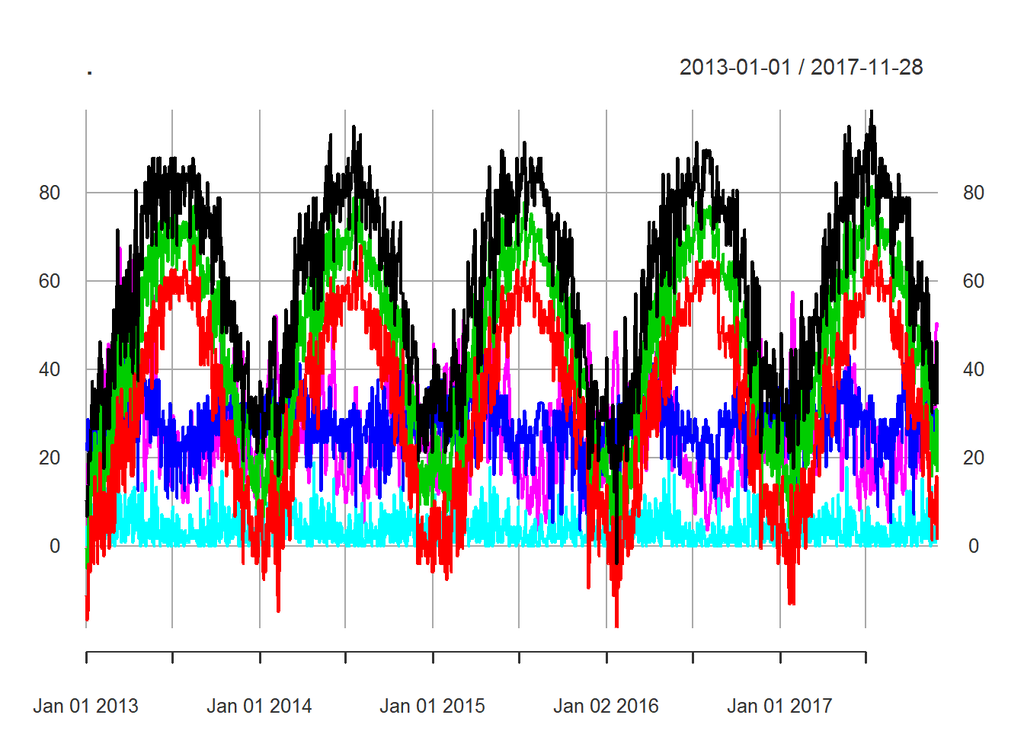

```r
require(xts)

xtdat = datong %>%
  select(-city, -county, -date) %>%
  xts(., order.by = datong$date)

datong %>%
  select(-city, -county, -date, -aqi) %>%
  xts(., order.by = datong$date) %>%
  plot()
```

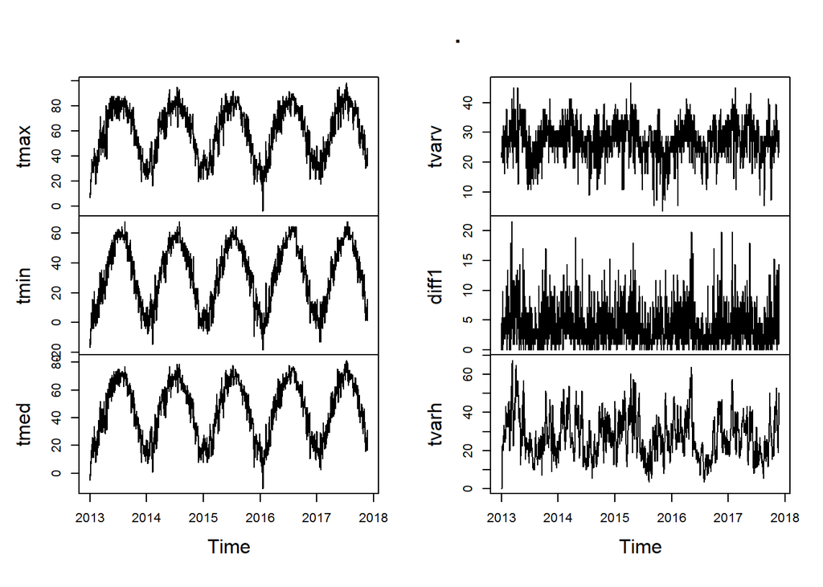

```r
datong %>%
  select(-city, -county, -date, -aqi) %>%
  ts(.,start = c(2013, 1, 1), frequency = 365) %>%
  plot()
```

Plot using `ggfortify`

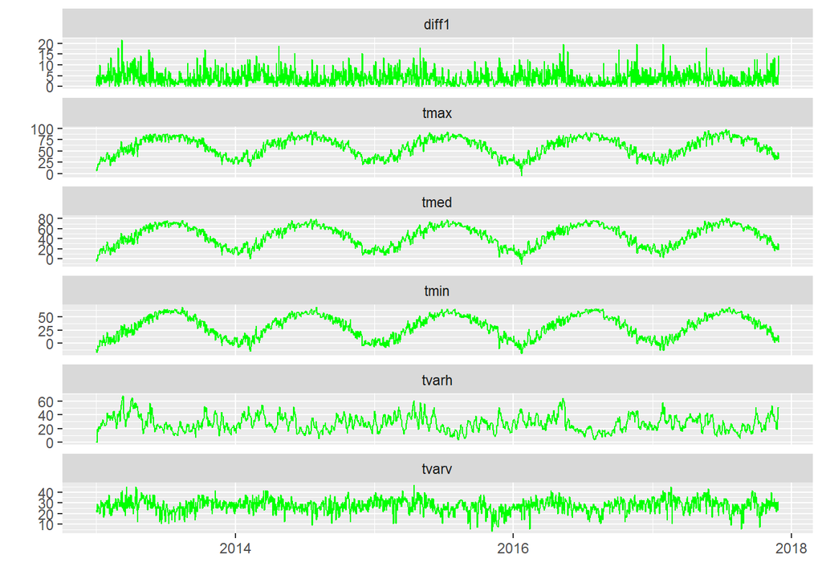

```r
library(ggfortify)

datong %>%
  select(-city, -county, -date, -aqi) %>%
  xts(., order.by = datong$date) %>%
  autoplot(ts.colour = "green")
```

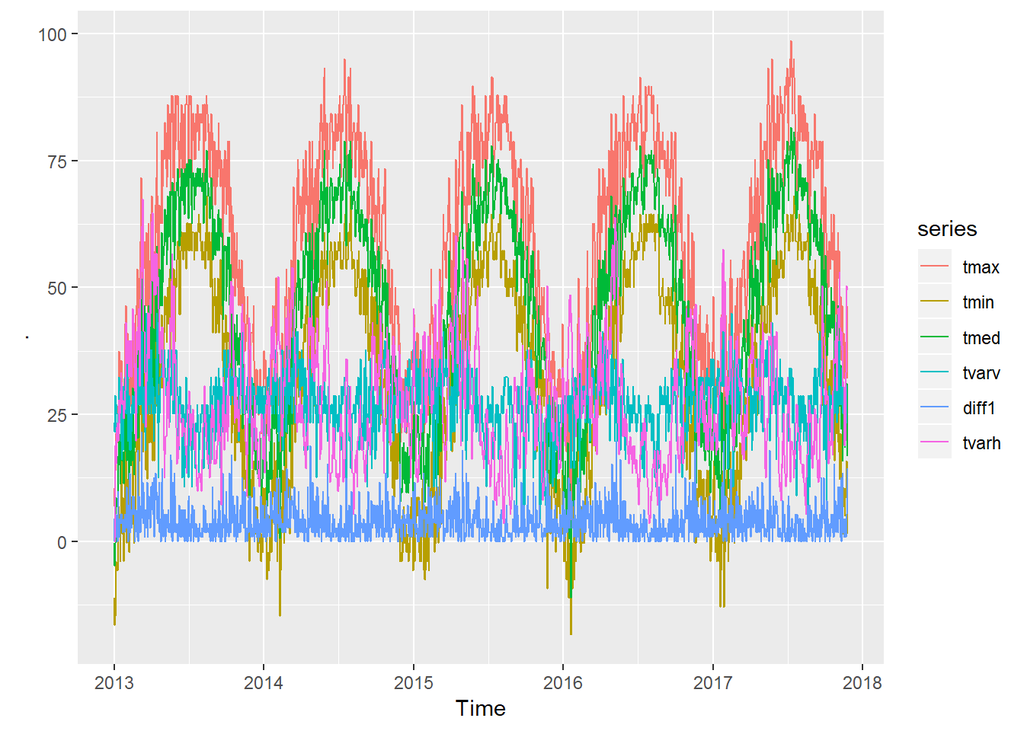

```r
datong %>%
  select(-city, -county, -date, -aqi) %>%
  ts(.,start = c(2013, 1, 1), frequency = 365) %>%
  autoplot(facets = FALSE)
```

# 2 Components of time series data

- Trend Component
- Seasonality Component
- Cyclical Component
- Random Component

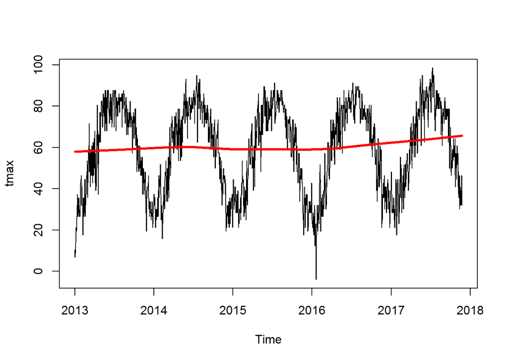

```r
library(Kendall)

t1 = datong %>%
  select(tmax) %>%
  ts(.,start = c(2013, 1, 1), frequency = 365)

plot(t1)
lines(lowess(time(t1), t1), lwd = 3, col = 2)
```

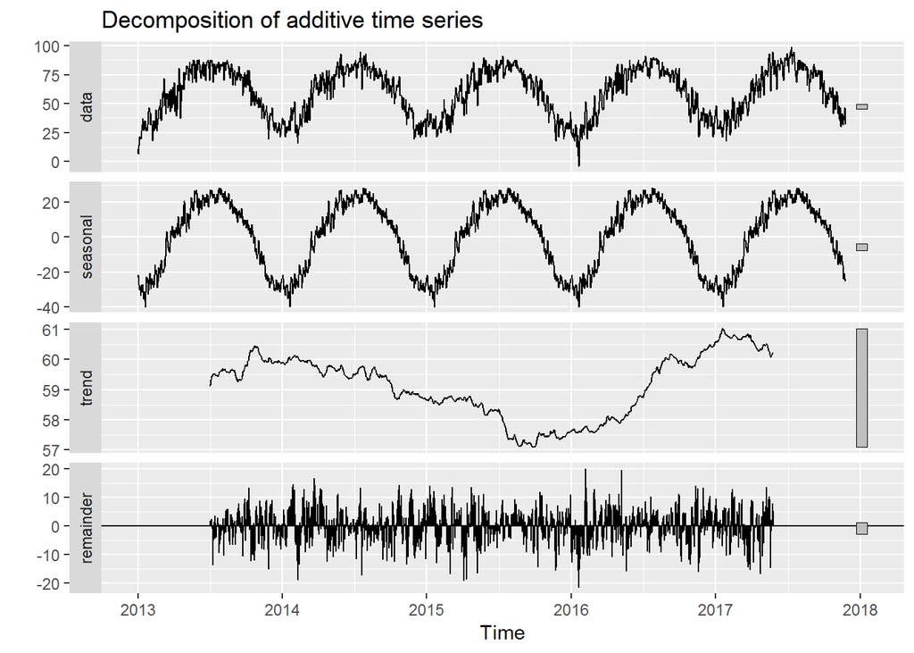

```r
autoplot(decompose(t1))
```

`autoplot(decompose(data))` plots four decomposed components:

- original data
- remainder
- seasonal component
- trend

## 2.1 Moving Averages (MA) for visualization

Moving average (MA) averages points across several time periods, thereby smoothing the observed data into a more stable predictable series.

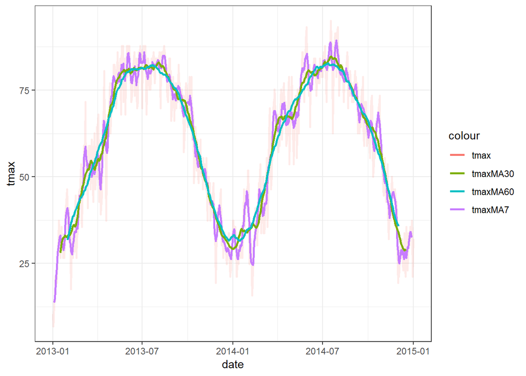

```r
library(forecast)

datongMA = datong %>%
  slice(1:730) %>%
  mutate(tmaxMA7 = ma(tmax, order = 7),
         tmaxMA30 = ma(tmax, order = 30),
         tmaxMA60 = ma(tmax, order = 60),
         tmaxMA90 = ma(tmax, order = 90))

datongMA %>%
  ggplot() +
  geom_line(data = datongMA, aes(date, tmax, color = 'tmax'), size = 1, alpha = 0.15) +
  geom_line(data = datongMA, aes(date, tmaxMA7, color = 'tmaxMA7'), size = 1) +
  geom_line(data = datongMA, aes(date, tmaxMA30, color = 'tmaxMA30'), size = 1) +
  geom_line(data = datongMA, aes(date, tmaxMA60, color = 'tmaxMA60'), size = 1) +
  theme_bw()
```

Is there a significant trend?

```r
library(tseries)

xx1 = factor(ifelse(datong$tmax >= median(datong$tmax), 1, 0))

runs.test(xx1, a = "less")
```

```
##
##  Runs Test
##
## data:  xx1
## Standard Normal = -36.235, p-value < 2.2e-16
## alternative hypothesis: less
```

- Friedman’s super smoother: We can also use the `supsmu()` function by specifying `span` variable as different values to detect the trend over time. `lines(supsmu(time(txdata), tsdata, span = 0.5))`
- splines: `lines(smooth.splin(time(txdata), txdata, spar = 1))`

## 2.2 Visualize monthly temporal data

```r
########### Monthly variations


library(fpp)
library(astsa)
library(DT)
library(dygraphs)

setwd("F:\\UltimateDS_R\\time lectures\\time data")

stck=read.csv("5stocks.csv")

tail(stck)

s=stck[,1:2]
head(s)

sts <- ts(s, frequency = 12, start = c(2001,7), end = c(2017,5))

plot.ts(sts[,2], main = "AAPL Stock Fluctuation", xlab = "Year", ylab = "ML")

seasonplot(sts[,2], year.labels = TRUE, year.labels.left=TRUE, col=1:40, pch=19, main = "Seasonal Variation in AAPL stocks", xlab = "Month", ylab = "ML")

## monthly plots

monthplot(sts[,2], year.labels = TRUE, year.labels.left=TRUE, col=1:40, pch=19, main = "Monthly Variation in AAPL stocks", xlab = "Month", ylab = "ML")

## Monthly variation-- boxplot

boxplot(sts[,2] ~ cycle(sts[,2]), xlab = "Month", ylab = "ML", main = "Monthly Variation in AAPL stocks")

##### Moving average smoothing to see the trend (smooth seasonality)

plot(sts[,2], col="gray", main = "1 Year Moving Average Smoothing")
lines(ma(sts[,2], order = 12), col = "red", lwd=3)

plot(sts[,2], col="gray", main = "3 Year Moving Average Smoothing")
lines(ma(sts[,2], order = 36), col = "red", lwd=3)

plot(sts[,2], col="gray", main = "10 Year Moving Average Smoothing")
lines(ma(sts[,2], order = 120), col = "red", lwd=3)
#by adding up the values of the last 10 yrs and
#dividing the sum by 10*12
```

## 2.3 Cyclical Behavior with Fourier Transforms

```r
###################################################################
###### Detect Cyclical Period Using Fourier

setwd("F:\\DataMining_R\\3_LectureData\\time")

g=read.csv("GlobalLandTemperaturesByCountry.csv")

head(g)

g=na.omit(g)

summary(g$Country)

########## china

chinaT=subset(g,Country=="China")
head(chinaT)
tail(chinaT)

names=c("dt","AverageTemperature")

chinaTemp=chinaT[,colnames(chinaT) %in% names]
head(chinaTemp)

library(TSA)


p = periodogram(chinaTemp$AverageTemperature)
#is used to identify the dominant periods (or frequencies) of a time series

#dominant spike at a low frequency

dd = data.frame(freq=p$freq, spec=p$spec)
order = dd[order(-dd$spec),]
top2 = head(order, 2)

top2

time = 1/top2$f#  it takes 12 time periods for a complete cycle

time

### would be more worhwhile to apply on daily e-commerce transitions
## and blog visits
```

## 2.4 STL Decomposition

```r
## time series into three components namely: the trend, seasonality and remainder

tsData = EuStockMarkets[, 1] # ts data
plot(tsData)
decomposedRes = decompose(tsData, type="mult")
# use type = "additive" for additive components
plot (decomposedRes) # see plot below

## stl decomposition
stlRes <- stl(tsData, s.window = "periodic")

seasonal_stck =stlRes$time.series[,1]
plot(seasonal_stck)

trend_stck =stlRes$time.series[,2]
plot(trend_stck)
```

STL decomposition decomposes time series data into three components:

- the trend
- seasonality
- remainder

## 2.5 More on seasonality data

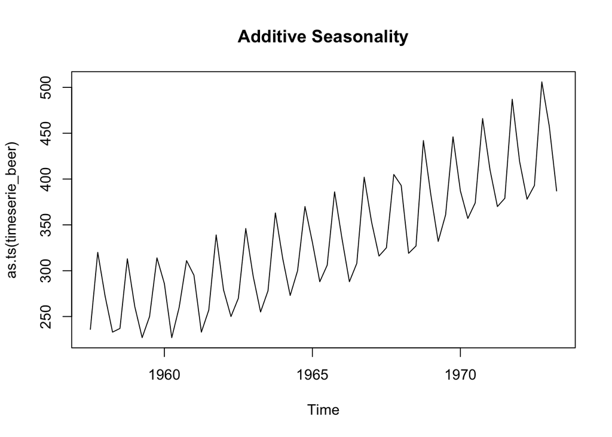

```r
############# More on seasonality

library(fpp)
library(forecast)

data(ausbeer)
timeserie_beer = tail(head(ausbeer, 17*4+2),17*4-4)
plot(as.ts(timeserie_beer),main="Additive Seasonality")
```

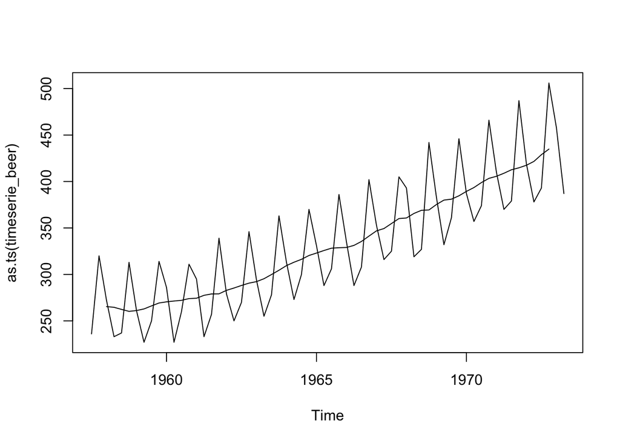

```r
trend_beer = ma(timeserie_beer, order = 4, centre = T) #ma of 4
plot(as.ts(timeserie_beer))
lines(trend_beer) #trend line
```

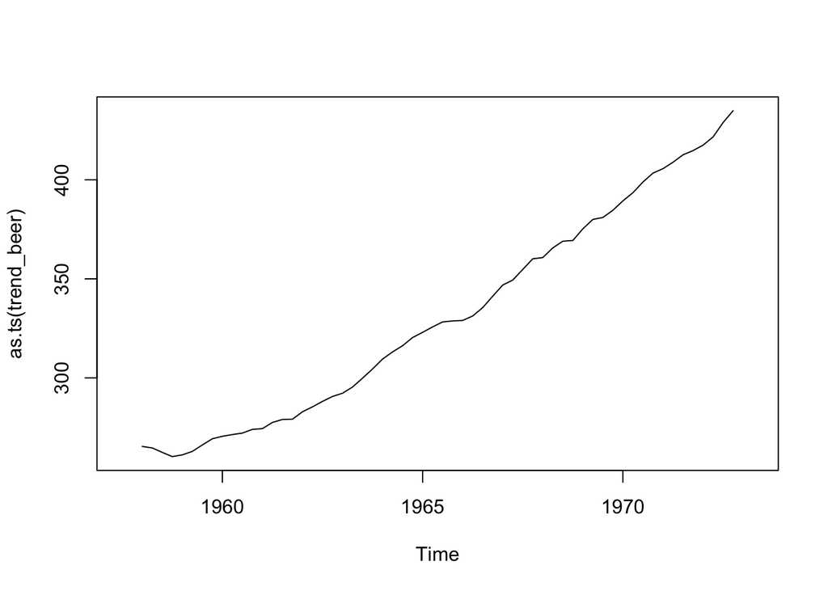

```r
plot(as.ts(trend_beer))
```

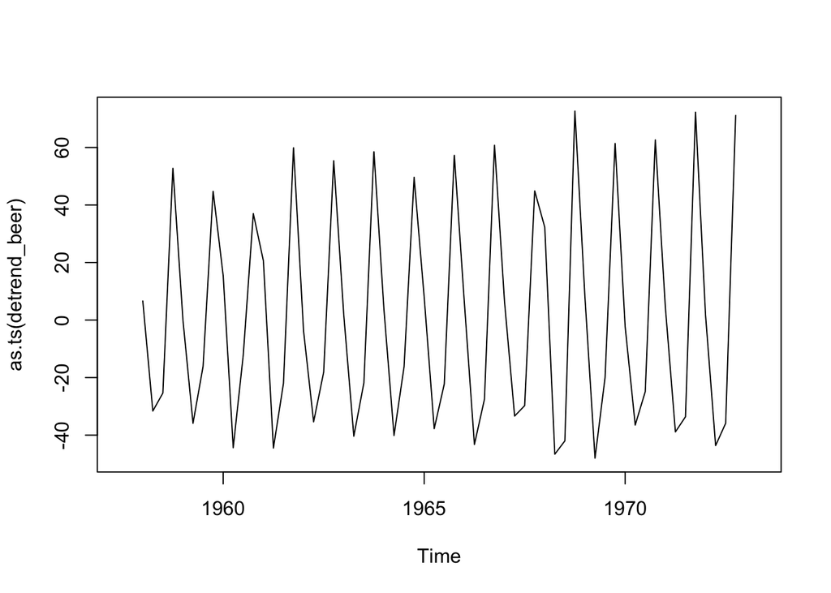

```r
##De-trend time series
## Remove trend to expose seasonality

detrend_beer = timeserie_beer - trend_beer
## subtract the previous trend in case of additive TS
plot(as.ts(detrend_beer))
```

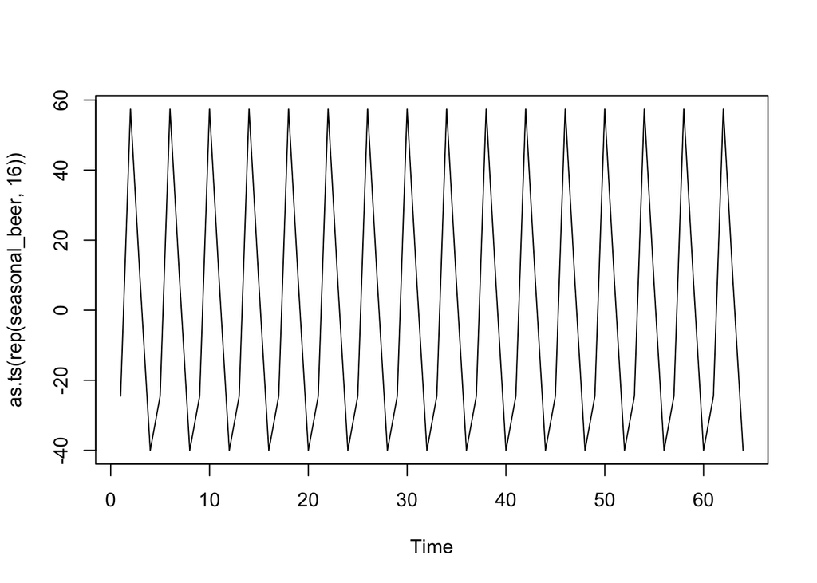

```r
##average seasonality
m_beer = t(matrix(data = detrend_beer, nrow = 4))
seasonal_beer = colMeans(m_beer, na.rm = T)
plot(as.ts(rep(seasonal_beer,16))) #repeat 16 times
```

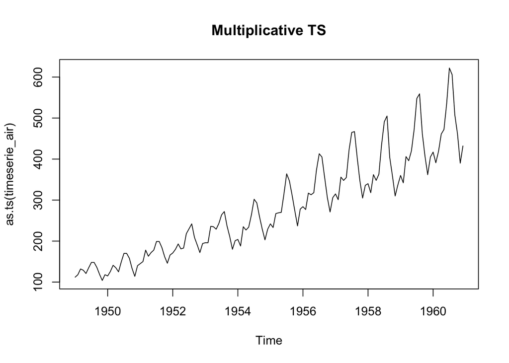

```r
######## Multiplicative seasonality
data(AirPassengers)
timeserie_air = AirPassengers
plot(as.ts(timeserie_air),main="Multiplicative TS")
```

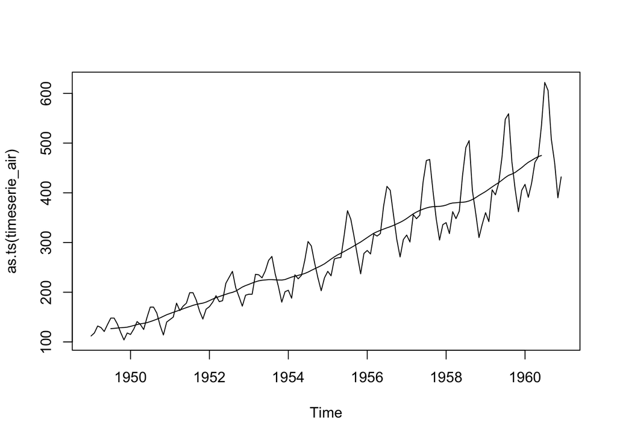

```r
trend_air = ma(timeserie_air, order = 12, centre = T)
#tskr previous 12 months
plot(as.ts(timeserie_air))
lines(trend_air)
```

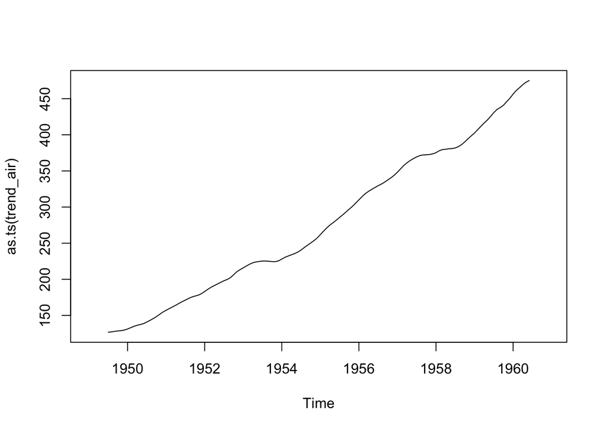

```r
plot(as.ts(trend_air))
```

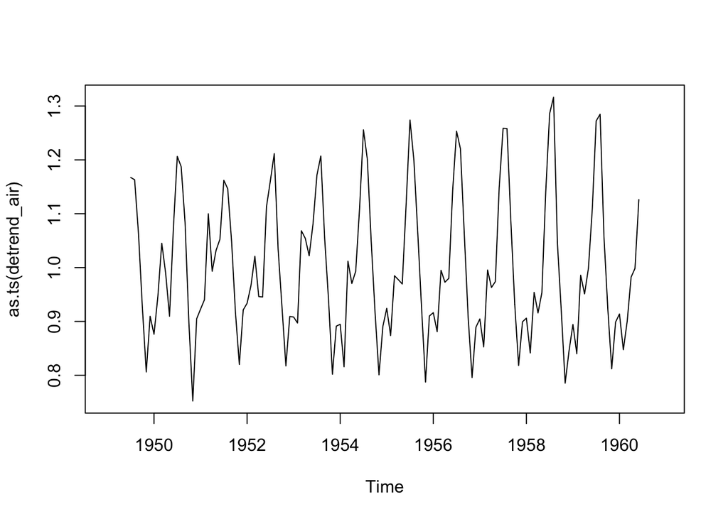

```r
detrend_air = timeserie_air / trend_air
### divide the previous trend in case of multiplicative TS
plot(as.ts(detrend_air))
```

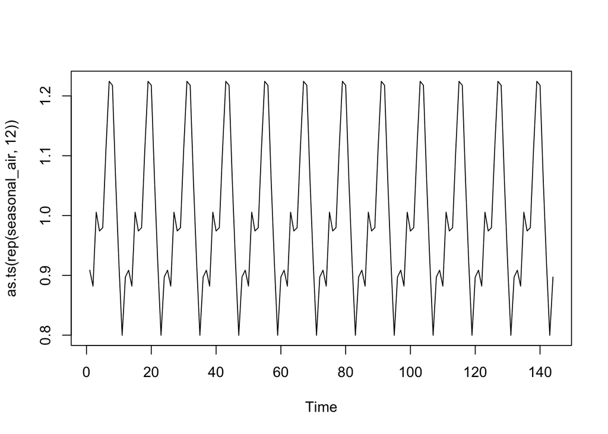

```r
##average seasonality
m_air = t(matrix(data = detrend_air, nrow = 12))
seasonal_air = colMeans(m_air, na.rm = T)
plot(as.ts(rep(seasonal_air,12)))
```